# HW_1- DATA VISUALIZATION

**Principles of Data Visualization and Introduction to ggplot2**

I have provided you with data about the 5,000 fastest growing companies in the US, as compiled by Inc. magazine. lets read this in:

```r
inc <- read.csv("https://raw.githubusercontent.com/charleyferrari/CUNY_DATA_608/master/module1/Data/inc5000_data.csv", header= TRUE)
```

And lets preview this data:

```r
head(inc)
```

|  | Rank | Name | Growth_Rate | Revenue | Industry | Employees | City | State |
| --- | --- | --- | --- | --- | --- | --- | --- | --- |
| 1 | 1 | Fuhu | 421.48 | 1.179e+08 | Consumer Products & Services | 104 | El Segundo | CA |
| 2 | 2 | FederalConference.com | 248.31 | 4.960e+07 | Government Services | 51 | Dumfries | VA |
| 3 | 3 | The HCI Group | 245.45 | 2.550e+07 | Health | 132 | Jacksonville | FL |
| 4 | 4 | Bridger | 233.08 | 1.900e+09 | Energy | 50 | Addison | TX |
| 5 | 5 | DataXu | 213.37 | 8.700e+07 | Advertising & Marketing | 220 | Boston | MA |
| 6 | 6 | MileStone Community Builders | 179.38 | 4.570e+07 | Real Estate | 63 | Austin | TX |

```r
NA
```

```r
summary(inc)
```

```
      Rank          Name            Growth_Rate         Revenue            Industry           Employees           City              State
 Min.   :   1   Length:5001        Min.   :  0.340   Min.   :2.000e+06   Length:5001        Min.   :    1.0   Length:5001        Length:5001
 1st Qu.:1252   Class :character   1st Qu.:  0.770   1st Qu.:5.100e+06   Class :character   1st Qu.:   25.0   Class :character   Class :character
 Median :2502   Mode  :character   Median :  1.420   Median :1.090e+07   Mode  :character   Median :   53.0   Mode  :character   Mode  :character
 Mean   :2502                      Mean   :  4.612   Mean   :4.822e+07                      Mean   :  232.7
 3rd Qu.:3751                      3rd Qu.:  3.290   3rd Qu.:2.860e+07                      3rd Qu.:  132.0
 Max.   :5000                      Max.   :421.480   Max.   :1.010e+10                      Max.   :66803.0
                                                                                            NA's   :12
```

Think a bit on what these summaries mean. Use the space below to add some more relevant non-visual exploratory information you think helps you understand this data:

## Rank

This is the rank of the company, presumably some combination of revenue and growth rate. A visual analysis of this will be best to decipher how the ranking is done.

## Growth Rate

This is the rate at which the companies are growing. Let us note that smaller companies will be more sensitive to change in size.

## Revenue

This will be how much money the company is pulling in. keep in mind this isn’t profit. We will see if this is relevant later.

## City/State

There might be some correlation between location, we should be careful about developing causal relationships with location because it might be due to factors outside this dataset

| Industry | n |
| --- | --- |
| IT Services | 733 |
| Business Products & Services | 482 |
| Advertising & Marketing | 471 |
| Health | 355 |
| Software | 342 |
| Financial Services | 260 |
| Manufacturing | 256 |
| Consumer Products & Services | 203 |
| Retail | 203 |
| Government Services | 202 |

[output cut: 15 more lines]

Maybe you could say that companies that provide services as opposed to products top the list.

## summary by industry

Note that the percent of the list taken up by an industry does not translate to revenue. Keep in mind that revenue does not equal profit. A company providing a service might make more profit because they don’t have to account for the cost of a product, and they might have less employees to pay for in order to produce the product. These things will be more easily investigated with graphs.

| Industry | growth_rate | revenue | employees |
| --- | --- | --- | --- |
| Computer Hardware | 4.1 | 270129545 | 220.8 |
| Energy | 9.6 | 126344954 | 242.5 |
| Food & Beverage | 3.6 | 98559542 | NA |
| Logistics & Transportation | 4.3 | 95745161 | NA |
| Consumer Products & Services | 8.8 | 73676847 | 224.0 |
| Construction | 3.4 | 70450802 | 155.6 |
| Telecommunications | 2.9 | 56855814 | NA |
| Business Products & Services | 3.5 | 54705187 | NA |
| Security | 3.4 | 52230137 | 562.5 |
| Environmental Services | 2.1 | 51741176 | 199.1 |

[output cut: 15 more lines]

## Question 1

Create a graph that shows the distribution of companies in the dataset by State (ie how many are in each state). There are a lot of States, so consider which axis you should use. This visualization is ultimately going to be consumed on a ‘portrait’ oriented screen (ie taller than wide), which should further guide your layout choices.

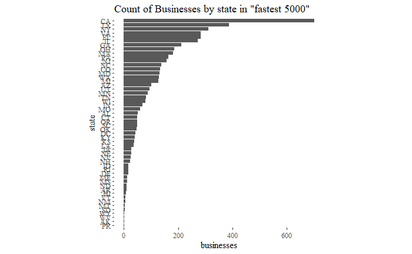

## Quesiton 2

Lets dig in on the state with the 3rd most companies in the data set. Imagine you work for the state and are interested in how many people are employed by companies in different industries. Create a plot that shows the average and/or median employment by industry for companies in this state (only use cases with full data, use R’s `complete.cases()` function.) In addition to this, your graph should show how variable the ranges are, and you should deal with outliers.

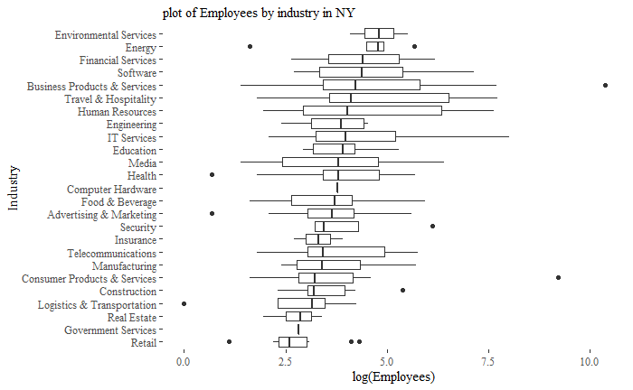

## Question 3

Now imagine you work for an investor and want to see which industries generate the most revenue per employee. Create a chart that makes this information clear. Once again, the distribution per industry should be shown.

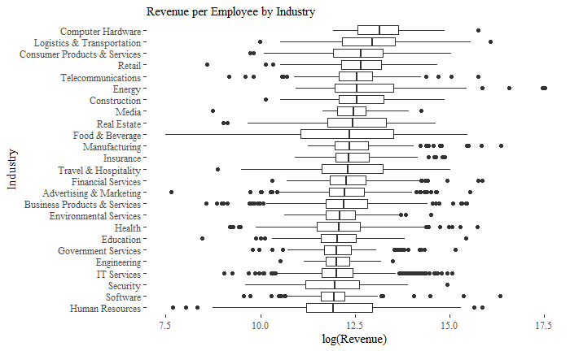